# ANALISI GEOSTATISTICA DEI DATI AMBIENTALI – Livello base (T28_25_3_1)

# Stazionarietà e isotropia

# Stazionarietà

La caratteristica di stazionarietà è fondamentale per molte tecniche geostatistiche

Stazionarietà di primo ordine: stazionarietà della media, ovvero un campione in due aree diverse della regione di studio hanno media uguale. Media quindi può essere costante (processo stazionario) o funzione dello spazio (trend deterministico) esempio la temperatura che cambia con la latitudine .

Stazionarietà di secondo ordine: stazionarietà della varianza, ovvero un campione in due aree diverse della regione di studio hanno varianza uguale.

# Stazionarietà - segue

Quasi sempre rappresenta una semplificazione della realtà.

La dimostrazione della stazionarietà in pratica è complesso per le seguenti ragioni:

1. **Dati limitati:** I dati geostatistici sono tipicamente sparsi e irregolarmente distribuiti, rendendo difficile valutare le proprietà statistiche sull’intera area di studio.
2. **Eterogeneità spaziale:** La maggior parte dei fenomeni naturali presenta una certa variabilità spaziale.
3. **Dipendenza dalla scala:** I pattern spaziali possono cambiare con la scala, complicando la valutazione della stazionarietà.

# Stazionarietà - esempio

Simulazione da un dataset completo temperatura, usando due transetti, vediamo effettivamente la difficoltà nel soddisfare queste condizioni:

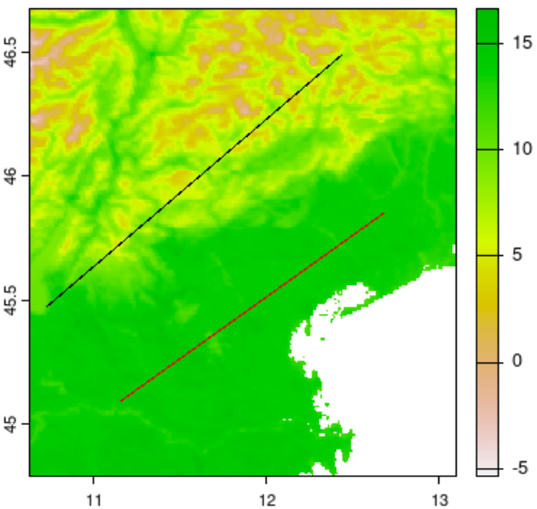

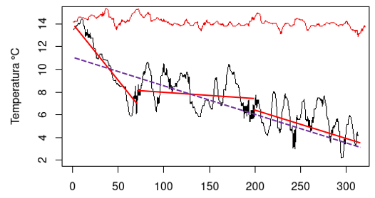

# Stazionarietà: Approcci pratici

Metodi per valutare il grado di stazionarietà:

- **Analisi esplorativa dei dati (EDA):**
  - Visualizzare i dati utilizzando istogrammi, scatter plot e mappe per identificare potenziali trend o pattern.
  - Calcolare statistiche descrittive (media, varianza) per diversi sottoinsiemi dei dati per verificare la consistenza.
- **Analisi del variogramma:**
  - Esaminare il variogramma per evidenziare la stazionarietà (ad esempio, raggiungimento di un plateau, comportamento isotropo).
  - Considerare l’adattamento di diversi modelli di variogramma per valutare la loro aderenza.

# Stazionarietà: Considerazioni importanti

- **La stazionarietà è spesso un’approssimazione:** In pratica, spesso si assume una stazionarietà approssimativa per applicare i metodi geostatistici.
- **Stazionarietà locale:** Può essere ragionevole assumere la stazionarietà all’interno di sottoregioni più piccole.
- **Metodi non stazionari:** Se la stazionarietà è chiaramente violata, considerare l’utilizzo di metodi geostatistici non stazionari (e.g. Universal Kriging o Regression Kriging) o altre tecniche di analisi spaziale.

**Ricorda:** L’obiettivo non è dimostrare la stazionarietà senza ombra di dubbio, ma valutare la sua plausibilità e prendere decisioni informate sull’adeguatezza dei metodi geostatistici

# Test di stazionarietà - variogramma

Insomma… i miei dati 2D soddisfano il presupposto di stazionarietà o no? O almeno quanto sono lontani da una perfetta stazionarietà?

NB - La stazionarietà è una decisione, non un’ipotesi (cit. M. Pyrcz); pertanto non può essere testata. I dati possono dimostrare che non è una supposizione appropriata.

La valutazione della stazionarietà dipende dalla scala. La scelta della scala deve basarsi sul problema specifico.

Per indagare/valutare la stazionarietà dei dati spaziali, in pratica la cosa migliore è usare un **variogramma o un autocorrelogramma**: - nel primo caso è un grafico che mostra come cambia il valore la covarianza a diversi lag.

# Variogramma

Per ogni coppia di punti a una determinata distanza, si calcola la metà della differenza al quadrato dei loro valori. Questa quantità è chiamata **semivarianza**. Il variogramma mette nell’asse X la distanza e nell’asse Y la semivarianza calcolata in funzione della distanza (h).

Il kriging utilizza il semivariogramma, o meglio un modello matematico del semivariogramma, per calcolare le stime della superficie ai nodi della griglia. Queste stime di kriging sono le migliori stime lineari oggettive della superficie nelle posizioni specificate, a condizione che la superficie sia stazionaria e che sia stata determinata la forma corretta del semivariogramma.

$$\gamma(h) = \tfrac{1}{2} \, \mathrm{Var}\big[ Z(s) - Z(s+h) \big]$$

# Perchè SEMIvarianza

- Serve a mantenere la relazione con la **varianza**:  
  quando $h→\infty$, la semivarianza tende alla **varianza della variabile** (non al doppio!)
- In pratica il fattore $\frac{1}{2}$ è una convenzione che garantisce che il semivariogramma sia coerente con le proprietà statistiche del processo.

# Semivarianza formula empirica

$$\hat{\gamma}(h) = \frac{1}{2N(h)} \sum_{i=1}^{N(h)} \Big( Z(s_i) -
Z(s_i+h) \Big)^2$$

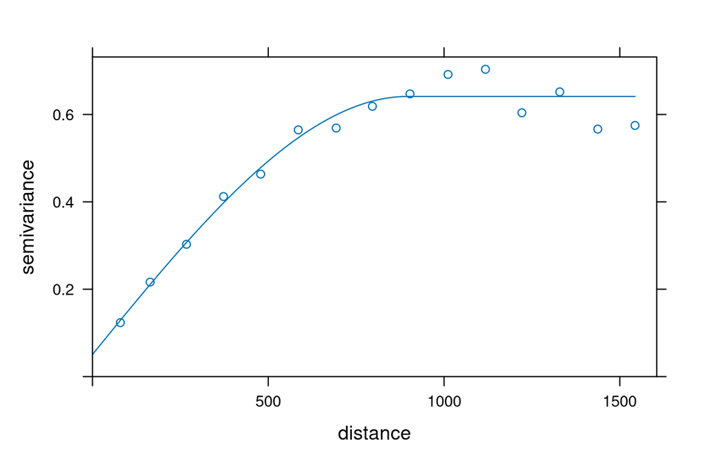

```r
lzn.vgm = variogram(log(zinc)~1, meuse)
#plot(lzn.vgm)
# prova a aggiungere argomento cloud=TRUE alla funzione variogram!
lzn.fit = fit.variogram(lzn.vgm, model = vgm(1, "Sph", 900, 1))
plot(lzn.vgm, lzn.fit)
```

- $Z(s_i)$ = valore osservato della variabile al punto $s_i$.
- $Z(s_i+h)$ = valore osservato al punto separato da distanza (o lag o intervallo di distanza solitamente nel semivario) $h$.
- $N(h)$ = numero di coppie di punti che distano circa $h$.
- La differenza al quadrato $(Z(s_i) - Z(s_i+h))^2$ misura la dissimilarità tra i due punti
- La somma fa la media di tutte le dissimilarità per le coppie a distanza $h$.

# Semivariogramma - attenzione

Ogni punto della nuvola rappresenta una coppia di punti nel set di dati, quindi il numero di punti nella nuvola aumenterà rapidamente all’aumentare del numero di punti nel set di dati. Per n punti nel set di dati, la nuvola di semivariogramma/covarianza visualizzerà

$$\frac{n*(n-1)}{2}$$

punti. Per questo motivo, non è consigliabile utilizzare set di dati con più di qualche migliaio di punti.

# Elementi del semivariogramma

- **Nugget:** Il valore iniziale del variogramma, indica la variabilità a brevissima distanza. Un nugget elevato suggerisce una componente casuale significativa.
- **Sill:** Il valore massimo a cui tende il variogramma, rappresenta la variabilità totale.
- **Portata:** La distanza alla quale il variogramma raggiunge il sill, indica la distanza oltre la quale i valori sono considerati indipendenti.

Il variogramma si dice delimitato se raggiunge un massimo tetto (sill) di varianza - vuol dire che c’è stazionarietà.

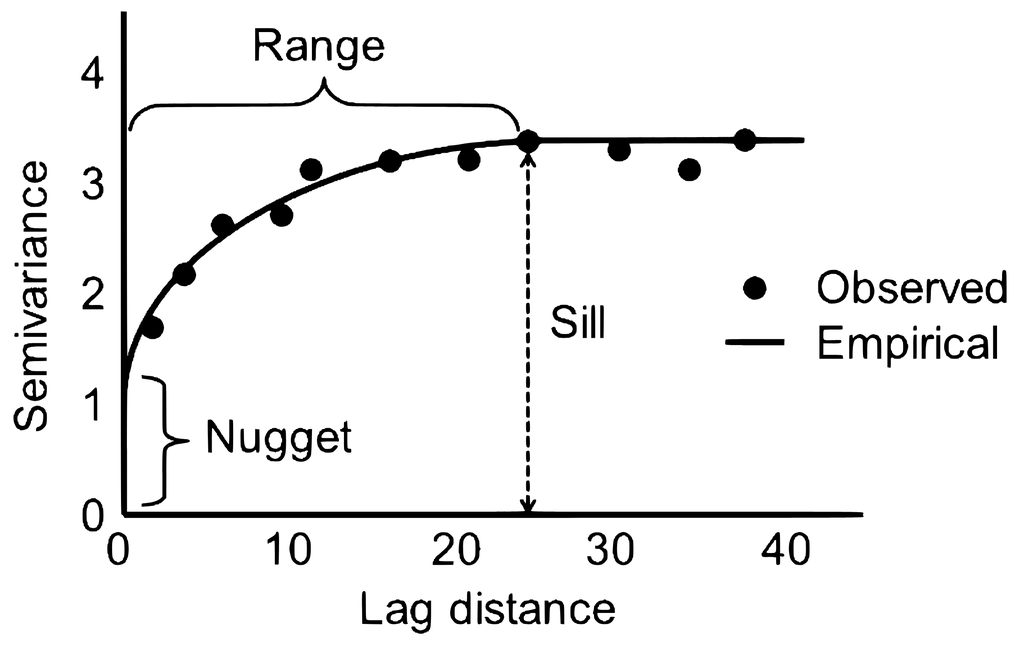

# Effetto nugget

E’ la varianza indipendente dall’autocorrelazione spaziale. Ad esempio dovuta agli errori di misura.

# Semivariogramma - cloud vs. plot

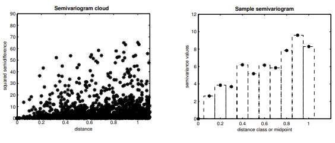

Fonte: Dr. Gaufeng Cao - University of Colorado Boulder

# Semivariogramma- esercizio interattivo

```r
lzn.vgm = variogram(log(zinc)~1, meuse, cloud=TRUE)

plot(plot(lzn.vgm, identify = TRUE), meuse)
# plot(plot(lzn.vgm, digitize = TRUE), meuse)
```

# Modelli di variogramma

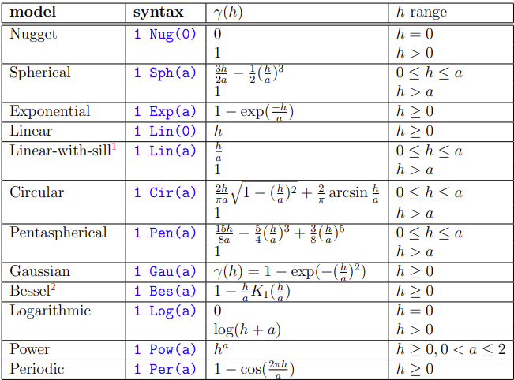

Courtesy of: GSTAT manual - https://www.gstat.org/gstat.pdf

# Modelli di variogramma (2)

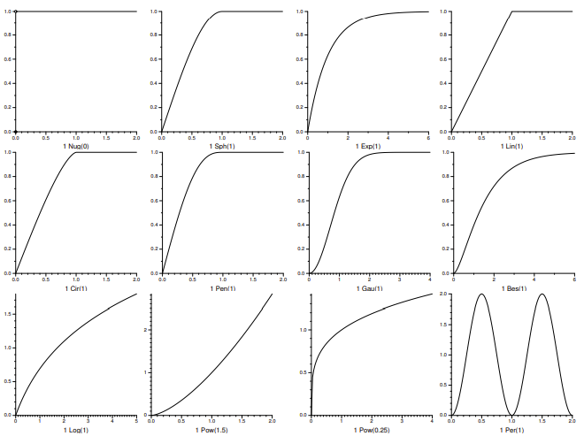

Courtesy of E.J. Pebesma - https://www.gstat.org/gstat.pdf

# Semivariogramma - esempi 1

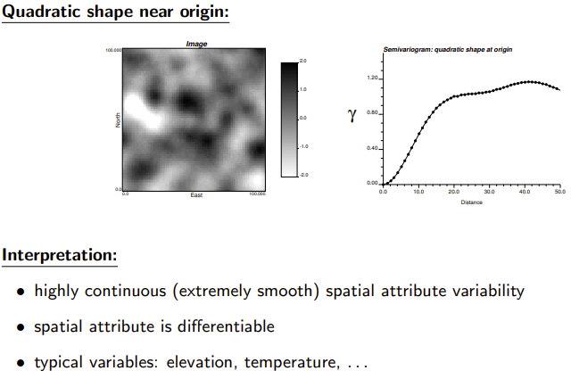

Fonte: Dr. Gaufeng Cao - University of Colorado Boulder

# Semivariogramma - esempi 2

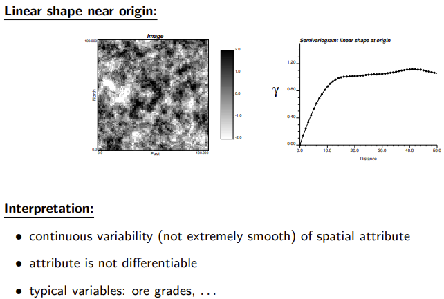

Fonte: Dr. Gaufeng Cao - University of Colorado Boulder

# Semivariogramma - esempi 3

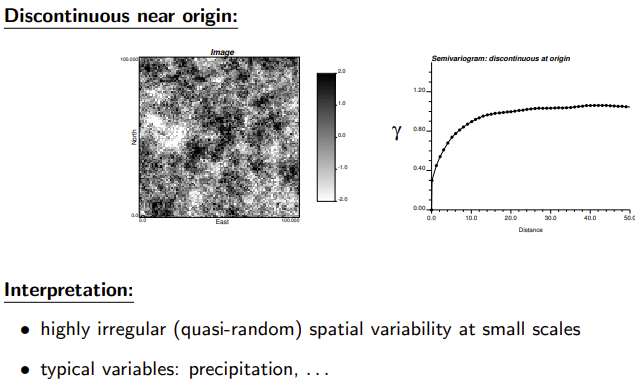

Fonte: Dr. Gaufeng Cao - University of Colorado Boulder

# Semivariogramma - esempi 4

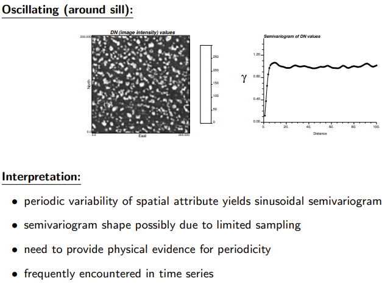

Fonte: Dr. Gaufeng Cao - University of Colorado Boulder

# Autocorrelogramma

Nel secondo caso è un grafico che mostra l’autocorrelazione dei valori dei dati a diversi lag (spaziali o temporali).

Si vuole studiare l’associazione tra le osservazioni della variabile analizzata in funzione di distanza e direzione. Le funzioni di covarianza, il correlogramma e il variogramma / il semivariogramma sono tutte funzioni che caratterizzano numericamente la forza di tali associazioni.

# Stazionarietà - variogramma

Il variogramma può aiutare a decidere se la variabile dipendente è stazionaria o meno.

**Forma coerente:** La forma complessiva del variogramma (ad esempio, sferica, esponenziale) deve rimanere coerente in diverse parti dell’area di studio.

**Nessuna tendenza sistematica:** Il variogramma non deve presentare tendenze chiare verso l’alto o verso il basso all’aumentare della distanza.

Vedi portale interattivo [Geospatial App](https://www.cirgeo.unipd.it/app01/GeospatialApp/)

# Isotropia

Direzionalità - si può testare fornendo un valore di *alpha* al variogramma.

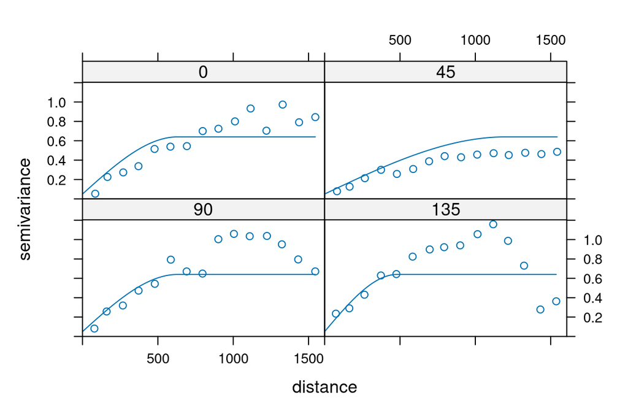

```r
lzn.dir = variogram(log(zinc)~1, meuse, alpha = c(0, 45, 90, 135))
lzndir.fit = vgm(.59, "Sph", 1200, .05, anis = c(45, .4))
plot(lzn.dir, lzndir.fit, as.table = TRUE)
```

# Variabili regionalizzate

Sono grandezze il cui valore dipende dalla localizzazione ovvero dal vettore delle [X Y] di coordinate spaziali.

La teoria delle variabili regionalizzate non utilizza l’autocorrelazione, ma una proprietà correlata chiamata semivarianza per esprimere il grado di relazione tra i punti di una superficie.

La semivarianza è semplicemente la metà della varianza delle differenze tra tutti i possibili punti distanziati da una distanza costante.

La semivarianza a una distanza d = 0 dovrebbe essere pari a zero, perché non ci sono differenze tra punti che vengono confrontati con se stessi. Tuttavia, man mano che i punti vengono confrontati con punti sempre più distanti, la semivarianza aumenta. A una certa distanza, chiamata intervallo,

la semivarianza diventerà approssimativamente uguale alla varianza della superficie stessa. Si tratta della massima distanza su cui il valore di un punto della superficie è correlato al valore di un altro punto. L’intervallo definisce il massimo vicinato su cui selezionare i punti di controllo per stimare un nodo della griglia, per sfruttare la correlazione statistica tra le osservazioni. Nel caso in cui il nodo della griglia e le osservazioni siano distanziate in modo tale che tutte le distanze superino l’intervallo, il kriging produce la stessa stima della statistica classica, ovvero la media.

# Giorno 3

# Giorno 3 - sommario

- Variogramma sperimentale e modello di variogramma: range, sill e nugget - esercizi
- Studio variografico di una variabile georeferenziata
  - verifica stazionarietà e isotropia
- Predizione e varianza di kriging
- Esercizi con Kriging

# Studio variografico

Condizione di isotropia - verifica.

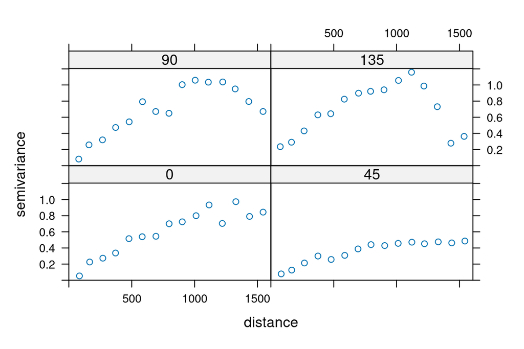

```r
#meuse$rand <- runif(nrow(meuse))

plot(variogram(log(zinc) ~ 1, meuse, alpha = c(0, 45,90, 135)))
```

# Studio variografico

Scala e densità di campioni (vedi app online per simulare campionamenti)

La distanza di **cutoff**, che è la distanza massima fino alla quale le coppie di punti vengono considerate, e il **width** è l’ampiezza dell’intervallo di distanza all’interno del quale le coppie di punti vengono mediate nei bin

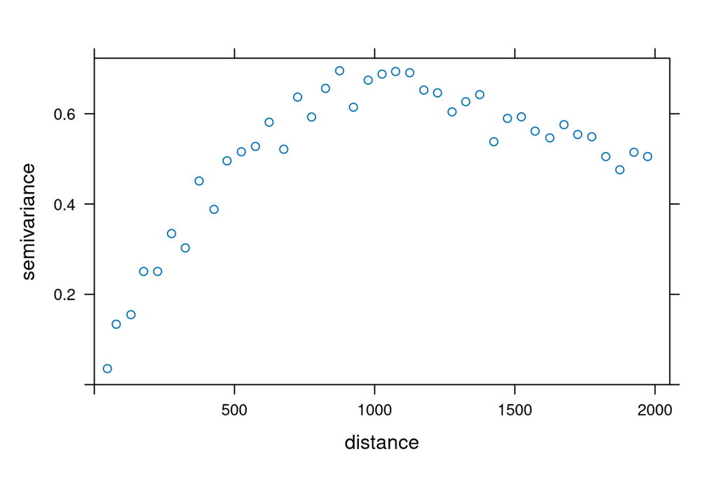

```r
plot(variogram(log(zinc) ~ 1, meuse, cutoff = 2000, width = 50))
```

# Studio variografico

Intervalli personalizzati

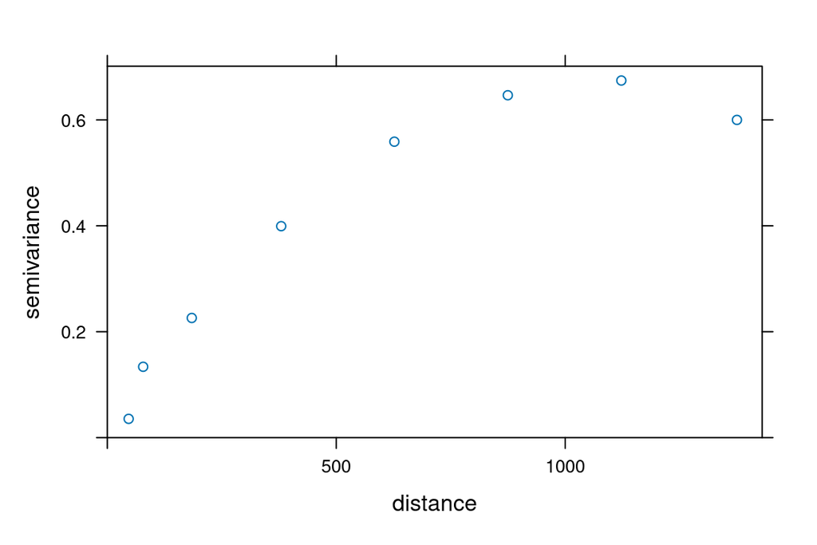

```r
v<-variogram(log(zinc) ~ 1, meuse, boundaries = c(0, 50,  100, seq(250, 1500, 250)))
plot(v)
```

# Stimare il modello ed i parametri

Gstat utilizza il metodo dei minimi quadrati per stimare i parametri di un modello che riteniamo possa essere adatto. Se i dati non sono coerenti con il modello, potrebbe dare una non-soluzione (singular fit) e non trovare i parametri del modello.

Esercizio - fornite voi a mano un sill, nugget e range (vedi documentazione vgm e Variogramma)

```r
 # show.vgms()
# NB come mai fornisce un singular fit?
v.fit <- fit.variogram(v, vgm(1, "Sph", 10, 1))
# ?vgm
```

# Stimare il modello ed i parametri

Se c’è anisotropia (l’autocorrelazione dipende dalla direzione oltre che dalla distanza reciproca) possiamo integrarlo nel modello imponendola

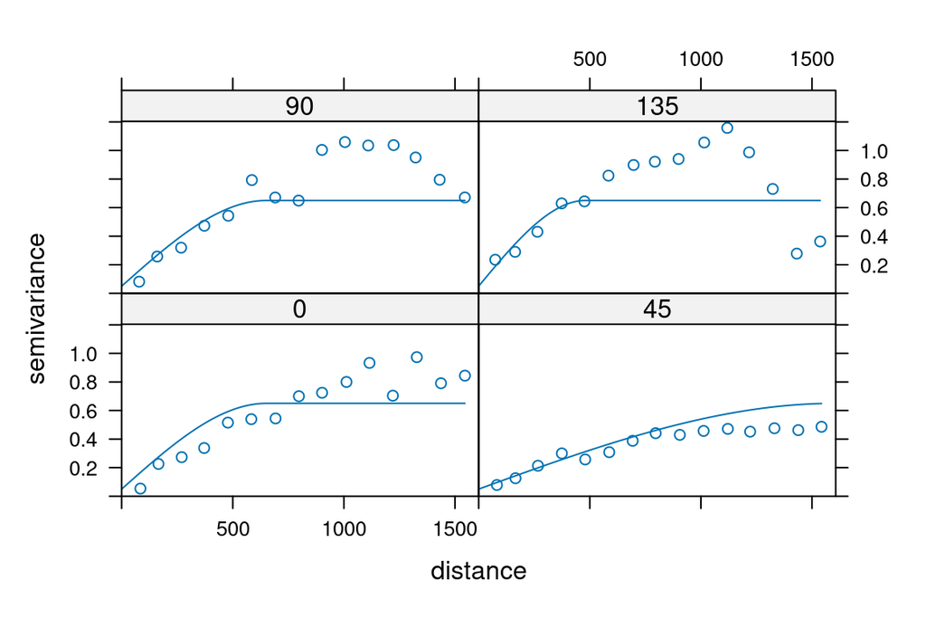

```r
v.dir <- variogram(log(zinc) ~ 1, meuse, alpha = (0:3) * 45)
v.anis <- vgm(0.6, "Sph", 1600, 0.05, anis = c(45, 0.3))
plot(v.dir, v.anis)
```

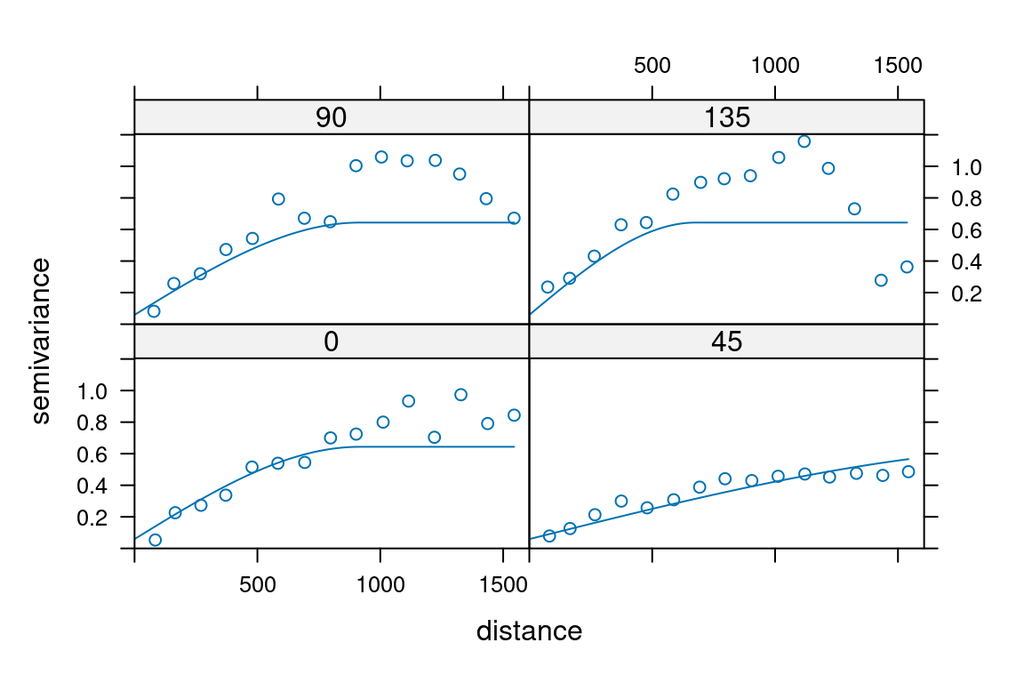

```r
v.fit <- fit.variogram(v.dir, v.anis)
plot(v.dir, v.fit)
```

# Anisotropia - stima direzione

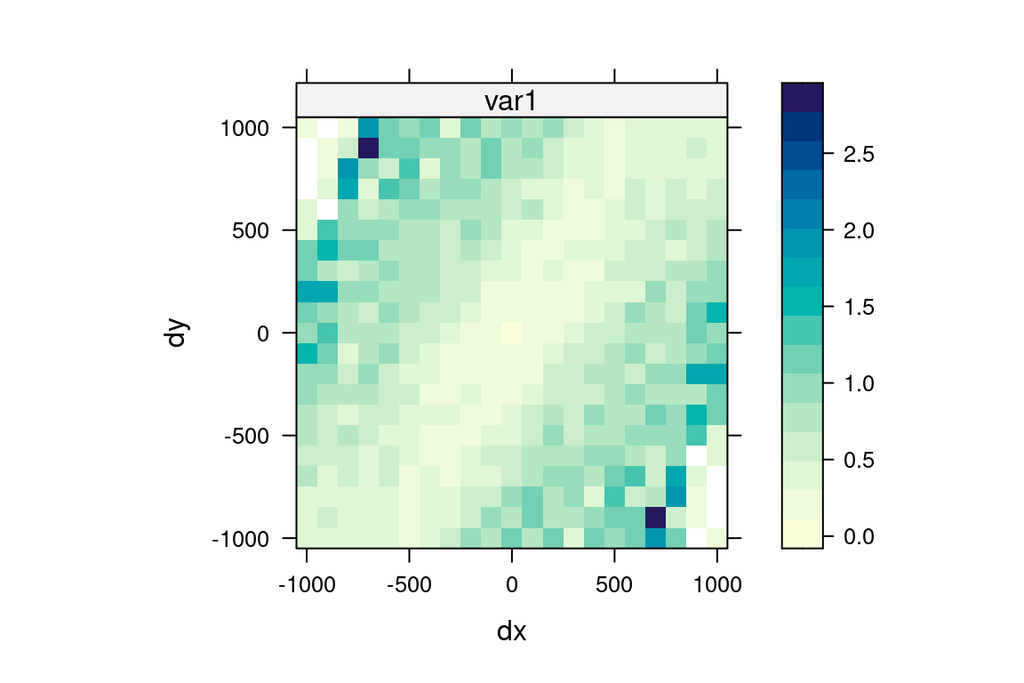

```r
plot(variogram(log(zinc) ~ 1, meuse, map = TRUE, cutoff = 1000,  width = 100))
```

# Interpolazione kriging

Una volta trovato il modello adatto possiamo usarlo per l’interpolatore usando la componente stocastica - ad esempio usiamo il modello che tiene in considerazione la leggera anisotropia dei nostri dati.

```r
v.dir <- variogram(log(zinc) ~ 1, meuse, alpha = (0:3) * 45)
v.anis <- vgm(0.6, "Sph", 1600, 0.05, anis = c(45, 0.3))
v.fit <- fit.variogram(v.dir, v.anis)
lz.sk <- krige(log(zinc) ~ 1, meuse, meuse.grid, v.fit, beta = 5.9)
```

```
## [using simple kriging]
```

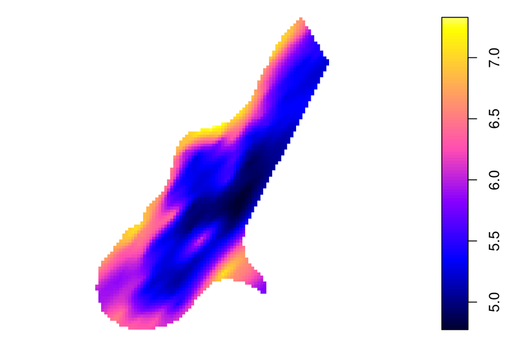

```r
plot(lz.sk)
```

# Interpolazione kriging - esercizio

Provate ad applicare la stessa cosa ad una variabile differente ed ad utilizzare TERRA per creare i due plot.

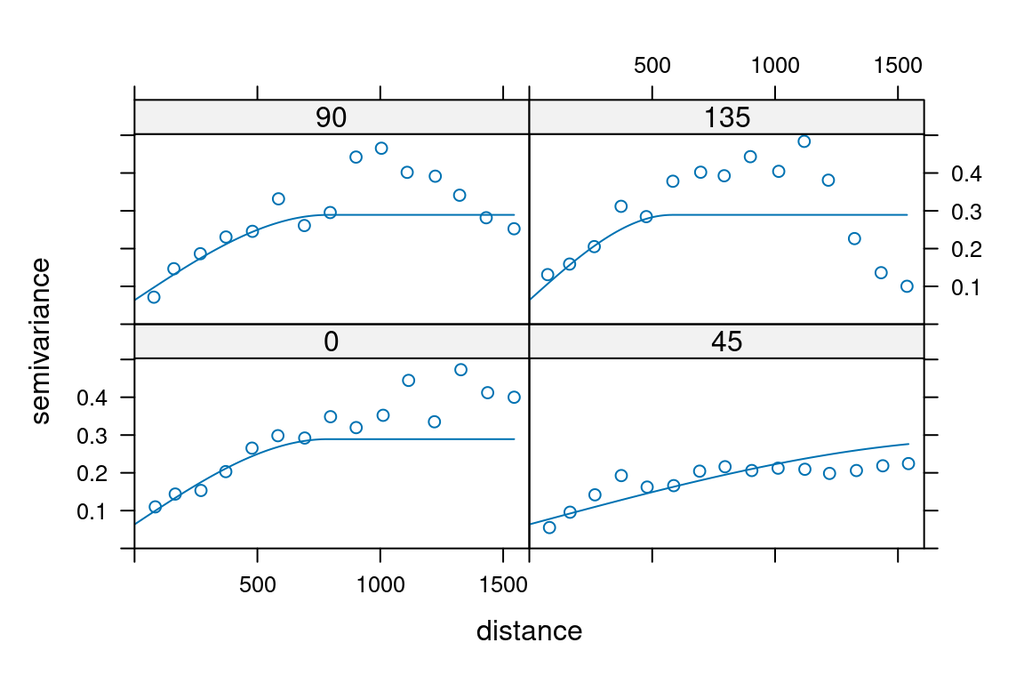

```r
v.dir2 <- variogram(log(copper) ~ 1, meuse, alpha = (0:3) * 45)
v.anis <- vgm(0.6, "Sph", 1600, 0.05, anis = c(45, 0.3))
v.fit <- fit.variogram(v.dir2, v.anis)
plot(v.dir2,  v.fit)
```

```r
lz.sk.cu <- krige(log(copper) ~ 1, meuse, meuse.grid, v.fit, beta = 5.9)
```

```
## [using simple kriging]
```

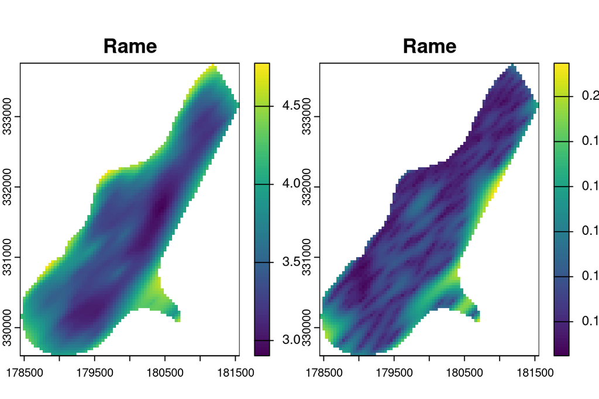

```r
plot(terra::rast(lz.sk.cu), main="Rame" )
```

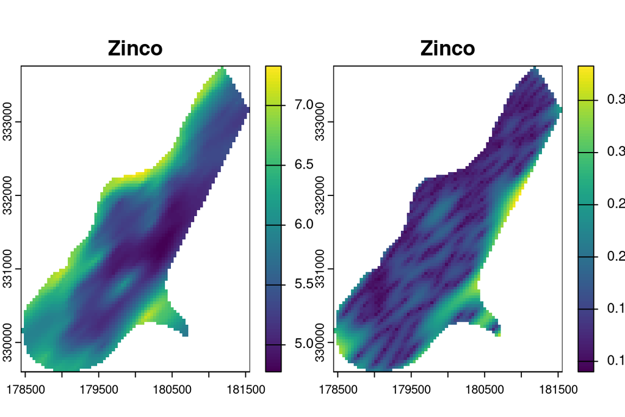

```r
plot(terra::rast(lz.sk), main="Zinco" )
```